# Bitcoin Fiyatlarının Doğrusal Olmayan Trendlere Uyan Bir Regresyon Modeli ile Tahmini

ELİF EKMEKCİ

2023-06-10

Bu uygulamada mevsimsellik ve tatil etkileri ile doğrusal olmayan trendlere uyan bir regresyon modeli uygulayarak tahminleme yapacağız. R programı kullanarak verimiz için **ds(tarih)**, standart tahmini kapanış fiyatı **yhat**, daha düşük tahmini kapanış fiyatı **that_lower** ve üst tahmini kapanış fiyatı **yhat_upper’ı** içeren bir vektör oluşturalım.

#### 1.ADIM

Analizimize başlamadan önce gerekli kütüphaneleri aktive edelim

```r
library(readxl) # excel dosyasindan veri ayiklamak icin
library(stringr) # model entegrasyonu icin dize degerlerini degistirmek icin
library(dplyr) # ilk ham veri kumesini islemek icin
library(prophet) # zaman serisi tahmin prosedurunu uygulamak icin
```

#### 2.ADIM

Verimizi çekelim ve my_data olarak isimlendirelim

```r
my_data <- read.csv("/Users/elif/Desktop/Bitcoin_prices.csv",header = T)
```

#### 3.ADIM

Verimizin ilk 6 ve son 6 gözlemini inceleyelim

```r
knitr::kable(head(my_data))
```

| Date | Open | High | Low | Close | Adj.Close | Volume |
| --- | --- | --- | --- | --- | --- | --- |
| 2014-09-18 | 456.860 | 456.860 | 413.104 | 424.440 | 424.440 | 34483200 |
| 2014-09-19 | 424.103 | 427.835 | 384.532 | 394.796 | 394.796 | 37919700 |
| 2014-09-20 | 394.673 | 423.296 | 389.883 | 408.904 | 408.904 | 36863600 |
| 2014-09-21 | 408.085 | 412.426 | 393.181 | 398.821 | 398.821 | 26580100 |
| 2014-09-22 | 399.100 | 406.916 | 397.130 | 402.152 | 402.152 | 24127600 |
| 2014-09-23 | 402.092 | 441.557 | 396.197 | 435.791 | 435.791 | 45099500 |

```r
knitr::kable(tail(my_data))
```

|  | Date | Open | High | Low | Close | Adj.Close | Volume |
| --- | --- | --- | --- | --- | --- | --- | --- |
| 3120 | 2023-04-03 | 28183.08 | 28475.62 | 27276.72 | 27790.22 | 27790.22 | 19556501327 |
| 3121 | 2023-04-04 | 27795.27 | 28433.74 | 27681.30 | 28168.09 | 28168.09 | 15284538859 |
| 3122 | 2023-04-05 | 28169.73 | 28739.24 | 27843.76 | 28177.98 | 28177.98 | 17052315986 |
| 3123 | 2023-04-06 | 28175.23 | 28178.38 | 27738.76 | 28044.14 | 28044.14 | 13837809380 |
| 3124 | 2023-04-07 | 28038.97 | 28111.59 | 27794.03 | 27925.86 | 27925.86 | 10861680497 |
| 3125 | 2023-04-08 | 27923.23 | 28158.27 | 27887.37 | 28032.19 | 28032.19 | 9243753472 |

#### 4.ADIM

Verimizde analizimiz için gerekli olan **Date** ve **Close** değişkenlerini seçelim ve bu gözlemlere ait ilk 6 gözlemini görüntüleyelim

```r
my_data2 = select(my_data, -2,-3,-4,-6,-7)
knitr::kable(head(my_data2))
```

| Date | Close |
| --- | --- |
| 2014-09-18 | 424.440 |
| 2014-09-19 | 394.796 |
| 2014-09-20 | 408.904 |
| 2014-09-21 | 398.821 |
| 2014-09-22 | 402.152 |
| 2014-09-23 | 435.791 |

#### 5.ADIM

**Tarih** sütun başlığını **ds** ile ve **Close** sütun başlığını **y** ile adlandıralım

```r
colnames(my_data2)[1] <- "ds"
colnames(my_data2)[2] <- "y"
knitr::kable(head(my_data2))
```

| ds | y |
| --- | --- |
| 2014-09-18 | 424.440 |
| 2014-09-19 | 394.796 |
| 2014-09-20 | 408.904 |
| 2014-09-21 | 398.821 |
| 2014-09-22 | 402.152 |
| 2014-09-23 | 435.791 |

#### 6.ADIM

Verimizdeki eksik gözlemleri (NA) 0 ile değiştirelim

```r
my_data2$y <- str_replace_all(my_data2$y, 'null', '0') #sutundaki tum bos degerleri 0'larla degistirir
knitr::kable(head(my_data2))
```

| ds | y |
| --- | --- |
| 2014-09-18 | 424.440002 |
| 2014-09-19 | 394.79599 |
| 2014-09-20 | 408.903992 |
| 2014-09-21 | 398.821014 |
| 2014-09-22 | 402.152008 |
| 2014-09-23 | 435.790985 |

#### 7.ADIM

Verimizin tahminini yapabilmemiz için mevsimsellik ve periyot ayarlarını yapalım

```r
Model1<-prophet(my_data2, daily.seasonality = TRUE)
Future1<-make_future_dataframe(Model1, periods = (365*1))
```

#### 8.ADIM

Bu adımda verimizin gelecek tahminlerini yapalım

```r
Forecast1<-predict(Model1,Future1)
knitr::kable(tail(Forecast1[c('ds','yhat','yhat_lower','yhat_upper')]))
```

|  | ds | yhat | yhat_lower | yhat_upper |
| --- | --- | --- | --- | --- |
| 3485 | 2024-04-02 | -4166.339 | -16895.44 | 8059.905 |
| 3486 | 2024-04-03 | -4285.350 | -17054.32 | 8383.644 |
| 3487 | 2024-04-04 | -4489.505 | -17374.86 | 7760.206 |
| 3488 | 2024-04-05 | -4649.182 | -17809.33 | 8372.853 |
| 3489 | 2024-04-06 | -4811.625 | -18016.08 | 7635.762 |
| 3490 | 2024-04-07 | -5026.957 | -18231.53 | 7683.809 |

Daha sonra bu tahminlerimizi gerçek veri setimizin üzerinde çizdirelim ve tahmin performansını gözlemleyelim

#### 9.ADIM

```r
dyplot.prophet(Model1,Forecast1)
```

[interactive chart not shown]

Grafiğe baktığımızda ince mavi çizgi tahmin edilen fiyat trendi, noktalı siyah çizgi ise zaman içindeki tarihsel fiyatı temsil etmektedir.

Grafikte 11 Şubat 2022 tarihini incelediğimizde güncel fiyat 42407.94 USD iken modelimiz 41082.79 USD olarak tahmin etmiştir.

1 Temmuz 2023 tarihi için modelimizin tahmin fiyatı 5555.2 USD’dir.

Modelimiz 1 Ocak 2024 tarihinde bitcoin fiyatını –1051.95 USD olarak tahmin etmiştir.

Ayrıca grafiğimiz incelendiğinde kurduğumuz tahmin modeline göre yeni yılda bitcoin fiyatının düşüşte olacağını öngörebiliriz

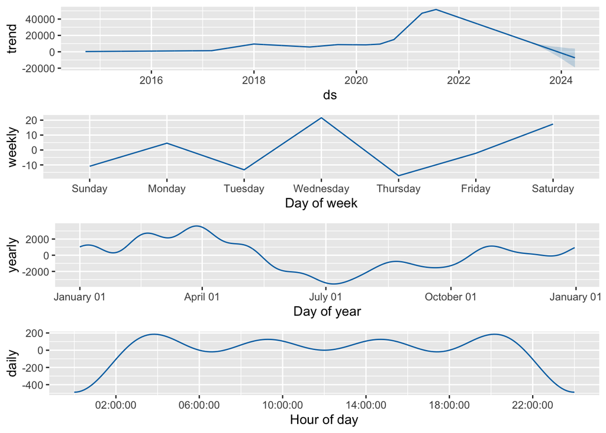

```r
prophet_plot_components(Model1,Forecast1)
```

Yukarıdaki grafiklerde ise günlük, haftalık ve yıllık aralıklarla yakalanan mevsimsel eğilimleri görebiliriz. Her ayın/yılın 15. günü için bir data frame oluşturup 2023-03-15 ve 2024-03-15 tarih aralığı filtreleyelim. Bu hedef yıl aralığını filtrelememizin amacı daha grenli bir görünüm elde etmektir.

#### 10.ADIM

Modelimizin gelecek yıl için tahminleri aşağıdaki gibidir:

```r
d<-data.frame(Forecast1[c('ds','yhat','yhat_lower','yhat_upper')])

Price_1_Year_Table<-d[format.Date(d$ds, "%d")=="15" &
                              !is.na(d$ds),]
```

```r
Truncated1 <- (subset(Price_1_Year_Table, ds>="2023-03-15"))
knitr::kable(Truncated1)
```

|  | ds | yhat | yhat_lower | yhat_upper |
| --- | --- | --- | --- | --- |
| 3101 | 2023-03-15 | 17949.485 | 12187.6617 | 23973.918 |
| 3132 | 2023-04-15 | 15459.495 | 9656.3376 | 20793.748 |
| 3162 | 2023-05-15 | 11625.689 | 6054.4733 | 17506.758 |
| 3193 | 2023-06-15 | 7584.257 | 1442.4787 | 13499.316 |
| 3223 | 2023-07-15 | 4775.317 | -947.7676 | 10454.013 |
| 3254 | 2023-08-15 | 5288.540 | -1247.4488 | 11743.609 |
| 3285 | 2023-09-15 | 2893.850 | -4123.2740 | 9786.692 |
| 3315 | 2023-10-15 | 2521.266 | -4843.6781 | 9313.995 |
| 3346 | 2023-11-15 | 1321.883 | -6710.3287 | 9129.379 |
| 3376 | 2023-12-15 | -1111.179 | -9736.3302 | 6805.846 |
| 3407 | 2024-01-15 | -1900.146 | -11226.8239 | 7864.926 |
| 3438 | 2024-02-15 | -2268.619 | -13207.4464 | 8483.030 |
| 3467 | 2024-03-15 | -3811.858 | -15693.7905 | 7422.954 |

```r
Truncated <- (subset(Price_1_Year_Table, ds>="2022-05-15"))
knitr::kable(Truncated)
```

|  | ds | yhat | yhat_lower | yhat_upper |
| --- | --- | --- | --- | --- |
| 2797 | 2022-05-15 | 33323.791 | 27500.9419 | 39155.465 |
| 2828 | 2022-06-15 | 29363.780 | 23660.2995 | 34873.445 |
| 2858 | 2022-07-15 | 26521.732 | 21021.4641 | 32037.833 |
| 2889 | 2022-08-15 | 27072.312 | 21237.5458 | 32575.516 |
| 2920 | 2022-09-15 | 24628.181 | 19251.6766 | 30366.390 |
| 2950 | 2022-10-15 | 24331.681 | 18478.0440 | 29802.687 |
| 2981 | 2022-11-15 | 23028.395 | 17313.1822 | 28916.320 |
| 3011 | 2022-12-15 | 20629.129 | 15282.1074 | 27032.804 |
| 3042 | 2023-01-15 | 19818.622 | 14353.9228 | 25418.092 |
| 3073 | 2023-02-15 | 19546.193 | 13986.7369 | 25185.001 |
| 3101 | 2023-03-15 | 17949.485 | 12187.6617 | 23973.918 |
| 3132 | 2023-04-15 | 15459.495 | 9656.3376 | 20793.748 |
| 3162 | 2023-05-15 | 11625.689 | 6054.4733 | 17506.758 |
| 3193 | 2023-06-15 | 7584.257 | 1442.4787 | 13499.316 |
| 3223 | 2023-07-15 | 4775.317 | -947.7676 | 10454.013 |
| 3254 | 2023-08-15 | 5288.540 | -1247.4488 | 11743.609 |
| 3285 | 2023-09-15 | 2893.850 | -4123.2740 | 9786.692 |
| 3315 | 2023-10-15 | 2521.266 | -4843.6781 | 9313.995 |
| 3346 | 2023-11-15 | 1321.883 | -6710.3287 | 9129.379 |
| 3376 | 2023-12-15 | -1111.179 | -9736.3302 | 6805.846 |
| 3407 | 2024-01-15 | -1900.146 | -11226.8239 | 7864.926 |
| 3438 | 2024-02-15 | -2268.619 | -13207.4464 | 8483.030 |
| 3467 | 2024-03-15 | -3811.858 | -15693.7905 | 7422.954 |

```r
knitr::kable(mean(Truncated$yhat))
```

| x |
| --- |
| 13417.03 |

```r
knitr::kable(mean(Truncated$yhat_lower))
```

| x |
| --- |
| 6682.173 |

```r
knitr::kable(mean(Truncated$yhat_upper))
```

| x |
| --- |
| 20093.12 |